# Activity Prediction Assignment

Juan Sánchez

28 de diciembre de 2017

## Introduction

The goal of this project is to predict the manner in which 6 people did some exercises using data from accelerometers on the belt, forearm, arm, and dumbell. Besides those data, for each realization we have the “classe” which indicates how well the exercise was performed. Data was provided by Human Activities Recognition project (http:/groupware.les.inf.puc-rio.br/har).

## Preparing and cleaning the data

Removing columns in which there is at least one NA value. This approach can be very restrictive but it’s a starting point. If the results obtained with the models are not good enough a different approach can be evaluated (e.g. only removing columns in which all values are NAs first and, then, removing just the rows with NAs).

```r
# Only columns w/o NAs are selected
trainingData_1 <-  trainingData[, colSums(is.na(trainingData)) == 0]
```

Keeping only attributes corresponding to accelerometers’ data. Again this approach can be revisited later if needed.

```r
testData_1<- testData[c(8:60)]
trainingData_1<- trainingData_1[c(8:60)]
```

Creating training and test subsets for crossvalidation:

```r
# Creating train and test for cross validation
inTrain <- createDataPartition(y=trainingData_1$classe, p=0.70, list=FALSE)
train <- trainingData_1[inTrain, ]
test<- trainingData_1[-inTrain, ]
```

## Building the models

First step is setting a seed for the sake of reproductibility.

```r
set.seed(11234)
```

Different models among the ones presented in the course will be applied here until either significative good results are obtained with one of them or all of them are applied unsucessfully.

### First model: Trees

The first attempt will be using *trees* through *caret* library. The model is built with the train dataset created before.

```r
# R trees
modFit.rpart <- train(classe ~ .,method="rpart",data=train)
save(modFit.rpart, file="modFit.rpart.Rdata")
print(modFit.rpart$finalModel)
```

```
## n= 13737
##
## node), split, n, loss, yval, (yprob)
##       * denotes terminal node
##
##  1) root 13737 9831 A (0.28 0.19 0.17 0.16 0.18)
##    2) roll_belt< 130.5 12586 8688 A (0.31 0.21 0.19 0.18 0.11)
##      4) pitch_forearm< -33.95 1073    5 A (1 0.0047 0 0 0) *
##      5) pitch_forearm>=-33.95 11513 8683 A (0.25 0.23 0.21 0.2 0.12)
##       10) magnet_dumbbell_y< 439.5 9737 6960 A (0.29 0.18 0.24 0.19 0.11)
##         20) roll_forearm< 121.5 6016 3515 A (0.42 0.18 0.18 0.16 0.06) *
##         21) roll_forearm>=121.5 3721 2505 C (0.074 0.19 0.33 0.23 0.18) *
##       11) magnet_dumbbell_y>=439.5 1776  880 B (0.03 0.5 0.043 0.23 0.19) *
##    3) roll_belt>=130.5 1151    8 E (0.007 0 0 0 0.99) *
```

The tree generated can be plotted with *rattle*;

```r
library(rattle)
```

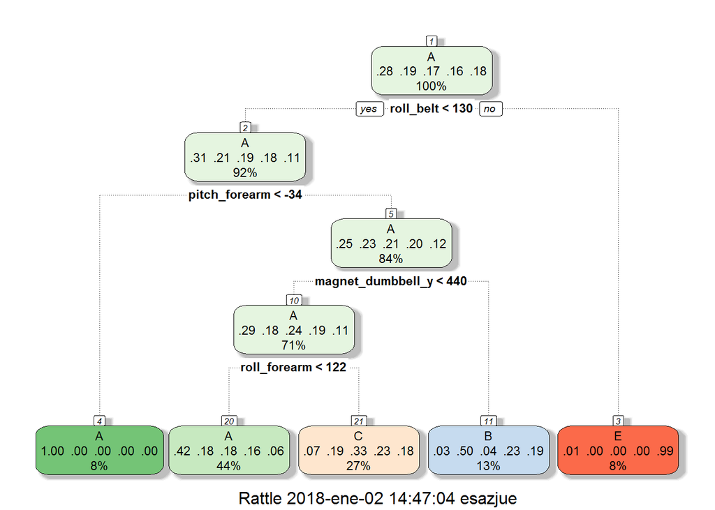

```r
fancyRpartPlot(modFit.rpart$finalModel)
```

In order to really estimated the goddness of the model, out of sample error is calculated with the test dataset.

```r
confusionMatrix(test$classe,predict(modFit.rpart,test[-c(53)]))
```

```
## Confusion Matrix and Statistics
##
##           Reference
## Prediction    A    B    C    D    E
##          A 1499   28  141    0    6
##          B  488  390  261    0    0
##          C  481   31  514    0    0
##          D  438  160  366    0    0
##          E  159  144  291    0  488
##
## Overall Statistics
##
##                Accuracy : 0.4912
##                  95% CI : (0.4784, 0.5041)
##     No Information Rate : 0.5208
##     P-Value [Acc > NIR] : 1
##
##                   Kappa : 0.335
##  Mcnemar's Test P-Value : NA
##
## Statistics by Class:
##
##                      Class: A Class: B Class: C Class: D Class: E
## Sensitivity            0.4891  0.51793  0.32676       NA  0.98785
## Specificity            0.9379  0.85405  0.88126   0.8362  0.88982
## Pos Pred Value         0.8955  0.34241  0.50097       NA  0.45102
## Neg Pred Value         0.6281  0.92351  0.78205       NA  0.99875
## Prevalence             0.5208  0.12795  0.26729   0.0000  0.08394
## Detection Rate         0.2547  0.06627  0.08734   0.0000  0.08292
## Detection Prevalence   0.2845  0.19354  0.17434   0.1638  0.18386
## Balanced Accuracy      0.7135  0.68599  0.60401       NA  0.93884
```

### Second model: Random Forrest

Next step will be applying Random Forrest algorithm. Due to some performance issues found with its implementation in *caret*, the library *randomForrest* is used in this part.

```r
# Random forrest
modFit.rf <- randomForest(classe ~ ., data=train)
save(modFit.rf, file="modFit.rf.Rdata")
cf.rf.train <- confusionMatrix(train$classe,predict(modFit.rf,train[-c(53)]))
cf.rf.train
```

```
## Confusion Matrix and Statistics
##
##           Reference
## Prediction    A    B    C    D    E
##          A 3906    0    0    0    0
##          B    0 2658    0    0    0
##          C    0    0 2396    0    0
##          D    0    0    0 2252    0
##          E    0    0    0    0 2525
##
## Overall Statistics
##
##                Accuracy : 1
##                  95% CI : (0.9997, 1)
##     No Information Rate : 0.2843
##     P-Value [Acc > NIR] : < 2.2e-16
##
##                   Kappa : 1
##  Mcnemar's Test P-Value : NA
##
## Statistics by Class:
##
##                      Class: A Class: B Class: C Class: D Class: E
## Sensitivity            1.0000   1.0000   1.0000   1.0000   1.0000
## Specificity            1.0000   1.0000   1.0000   1.0000   1.0000
## Pos Pred Value         1.0000   1.0000   1.0000   1.0000   1.0000
## Neg Pred Value         1.0000   1.0000   1.0000   1.0000   1.0000
## Prevalence             0.2843   0.1935   0.1744   0.1639   0.1838
## Detection Rate         0.2843   0.1935   0.1744   0.1639   0.1838
## Detection Prevalence   0.2843   0.1935   0.1744   0.1639   0.1838
## Balanced Accuracy      1.0000   1.0000   1.0000   1.0000   1.0000
```

As before, out of sample error is calculated with the test dataset.

```r
confusionMatrix(test$classe,predict(modFit.rf,test[-c(53)]))
```

```
## Confusion Matrix and Statistics
##
##           Reference
## Prediction    A    B    C    D    E
##          A 1673    1    0    0    0
##          B    7 1132    0    0    0
##          C    0    5 1018    3    0
##          D    0    0    6  957    1
##          E    0    0    0    5 1077
##
## Overall Statistics
##
##                Accuracy : 0.9952
##                  95% CI : (0.9931, 0.9968)
##     No Information Rate : 0.2855
##     P-Value [Acc > NIR] : < 2.2e-16
##
##                   Kappa : 0.994
##  Mcnemar's Test P-Value : NA
##
## Statistics by Class:
##
##                      Class: A Class: B Class: C Class: D Class: E
## Sensitivity            0.9958   0.9947   0.9941   0.9917   0.9991
## Specificity            0.9998   0.9985   0.9984   0.9986   0.9990
## Pos Pred Value         0.9994   0.9939   0.9922   0.9927   0.9954
## Neg Pred Value         0.9983   0.9987   0.9988   0.9984   0.9998
## Prevalence             0.2855   0.1934   0.1740   0.1640   0.1832
## Detection Rate         0.2843   0.1924   0.1730   0.1626   0.1830
## Detection Prevalence   0.2845   0.1935   0.1743   0.1638   0.1839
## Balanced Accuracy      0.9978   0.9966   0.9962   0.9951   0.9990
```

## Conclusions

After analyzing the obtained results, it cam be concluded that Random Forrest algorithm is a sensitive alternative to determined whether or not exercise was properly performed based on accelerometers readings.

For the sake of completeness, predictions obtained after applying the algorithm to the testData follow:

```r
predict(modFit.rf,testData)
```

```
##  1  2  3  4  5  6  7  8  9 10 11 12 13 14 15 16 17 18 19 20
##  B  A  B  A  A  E  D  B  A  A  B  C  B  A  E  E  A  B  B  B
## Levels: A B C D E
```